# Linear/Quadratic Discriminant Analysis

## Assignment 1: Figure 5.4

Build reasonable replications of the two graphs in Figure 5.4, page 180 of ISLR. For the right-hand graph, start by just producing one 10-Fold plot. If that works, think about how to layer nine of them on top of each other!

What does the result tell you about the best degree to use in a linear model (ie. in lm) in orger to predict mpg as a function of horsepower?

Hint: After you get an idea of how to do this, you might want to eventually to build a simple function that takes a value of the degree and returns the CV estimate of the error (for both LOOCV and k-Fold).

```r
compMSEdegree <- function(deg){
  (form <- buildFormAuto(deg))
  n <- nrow (auto.df)
  numFolds <- 10
  msevals <- numeric(numFolds)
  folds <- sample(1:numFolds, n , rep=T)
  for(fold in 1:numFolds){
    train.df <- auto.df[folds != fold,]
    test.df <- auto.df[folds == fold,]
    mod <- lm(formula(form), data = train.df)
    pred <- predict(mod, newdata = test.df)
    msevals[fold] <- with(test.df, mean((mpg-pred)^2))
  }
  mean(msevals)
}
  compMSEdegree(7)
```

```
## [1] 18.79099
```

##plot:

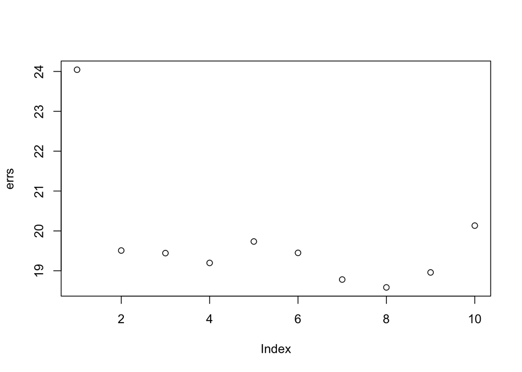

```r
degs <- 1:10
errs <- map_dbl(degs,compMSEdegree)

plot (errs)
```

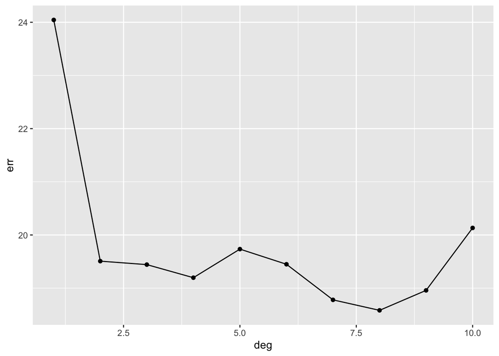

```r
data.frame(deg=degs, err=errs) %>%
  ggplot()+
  geom_point(aes(deg,err))+
  geom_line(aes(deg,err))
```

#cross validation

```r
numRuns <- 9
errsDegs <- matrix(nrow=10,
ncol=numRuns)
##Here we go
for(run in 1:numRuns){
errsDegs[,run] <- map_dbl(degs,compMSEdegree)
}
```

put into dataframe

```r
errsDegs.df <- data.frame( errsDegs)
##assign names
names(errsDegs.df) <- paste0("run",1:numRuns)
##add degrees
errsDegs.df$deg <- degs
```

plot!

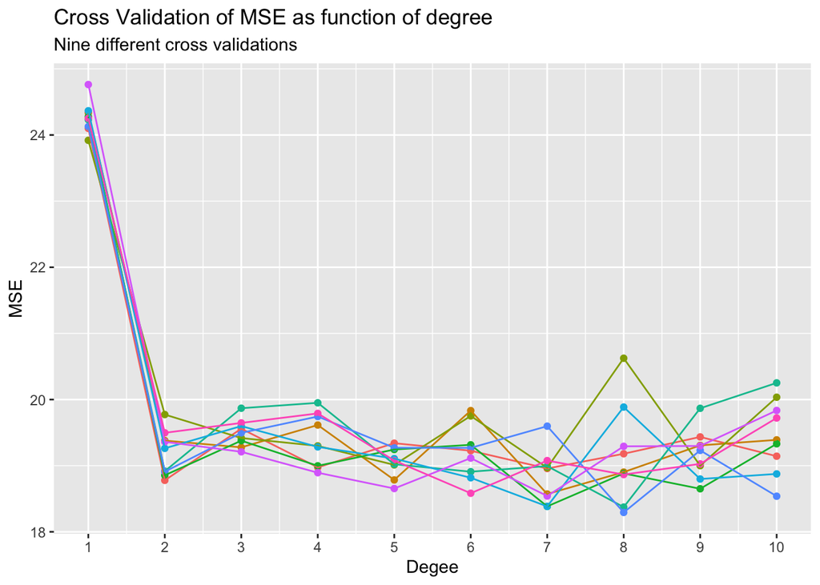

```r
errsDegs.df %>%
  gather(run,err,run1:run9) %>%
  ggplot()+
  geom_point(aes(deg,err,color=run))+
  geom_line(aes(deg,err,color=run))+
  scale_x_continuous(breaks=1:10)+
  labs(title="Cross Validation of MSE as function of degree",
       subtitle="Nine different cross validations",
       x="Degee",y="MSE")+
  guides(color=FALSE)
```